# Obligatorio Analisis de Regresión

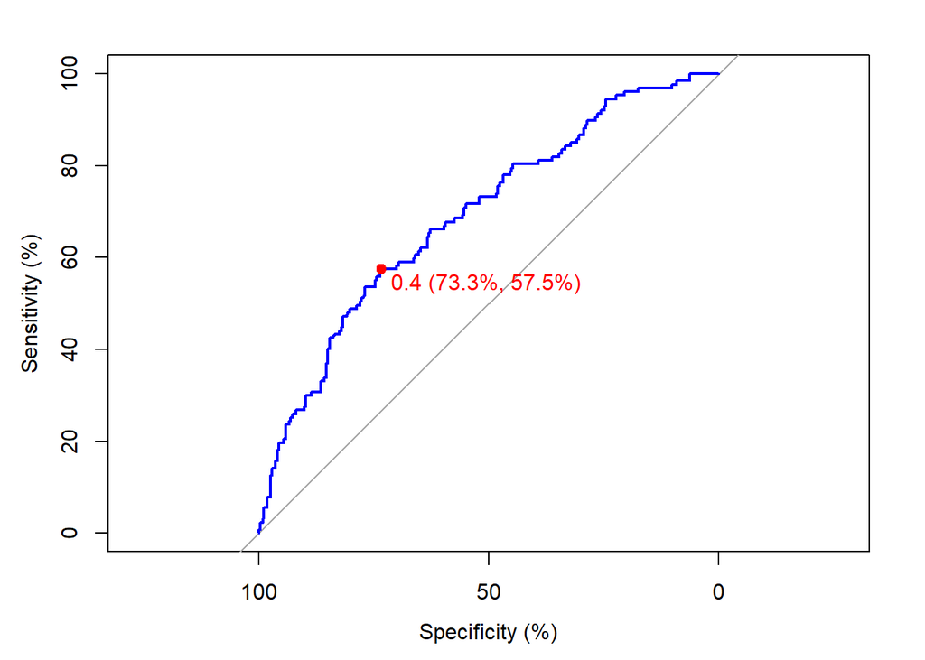

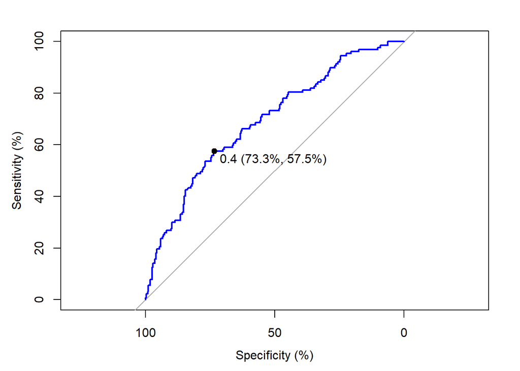

```
##   threshold
## 1 0.3536984
```

```
##   threshold
## 1 0.3536984
```

```
##           threshold accuracy sensitivity specificity       tpr       fpr
## threshold 0.3536984     0.69   0.5748031   0.7435897 0.5748031 0.2564103
```

```
##           threshold accuracy sensitivity 1-specificity       tpr       fpr
## threshold 0.3536984     0.69   0.5748031     0.2564103 0.5748031 0.2564103
```

```
##       threshold     specificity     sensitivity        accuracy              tn
##       0.3536984       0.7435897       0.5748031       0.6900000     203.0000000
##              tp              fn              fp             npv             ppv
##      73.0000000      54.0000000      70.0000000       0.7898833       0.5104895
##             fdr             fpr             tpr             tnr             fnr
##       0.4895105       0.2564103       0.5748031       0.7435897       0.4251969
##   1-specificity   1-sensitivity      1-accuracy           1-npv           1-ppv
##       0.2564103       0.4251969       0.3100000       0.2101167       0.4895105
##       precision          recall          youden closest.topleft
##       0.5104895       0.5748031       1.3183929       0.2465386
```

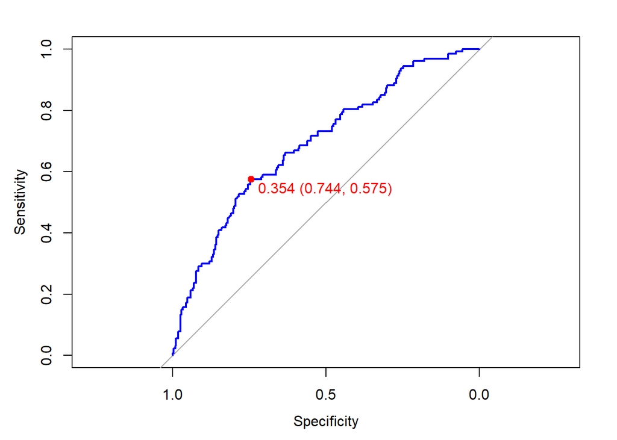

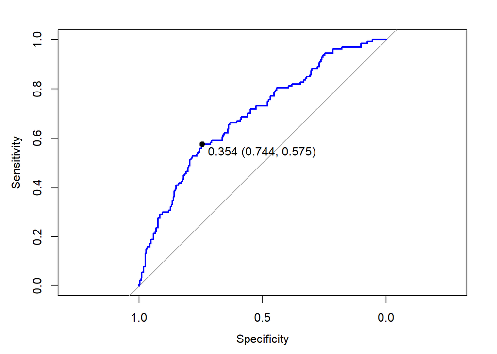

```
##   threshold
## 1 0.3728396
```

```
##   threshold
## 1 0.3728396
```

```
##           threshold accuracy sensitivity specificity       tpr       fpr
## threshold 0.3728396   0.7025   0.5354331   0.7802198 0.5354331 0.2197802
```

```
##           threshold accuracy sensitivity 1-specificity       tpr       fpr
## threshold 0.3161047   0.6425   0.6614173     0.3663004 0.6614173 0.3663004
```

```
##       threshold     specificity     sensitivity        accuracy              tn
##       0.3728396       0.7802198       0.5354331       0.7025000     213.0000000
##              tp              fn              fp             npv             ppv
##      68.0000000      59.0000000      60.0000000       0.7830882       0.5312500
##             fdr             fpr             tpr             tnr             fnr
##       0.4687500       0.2197802       0.5354331       0.7802198       0.4645669
##   1-specificity   1-sensitivity      1-accuracy           1-npv           1-ppv
##       0.2197802       0.4645669       0.2975000       0.2169118       0.4687500
##       precision          recall          youden closest.topleft
##       0.5312500       0.5354331       1.3156529       0.2641258
```

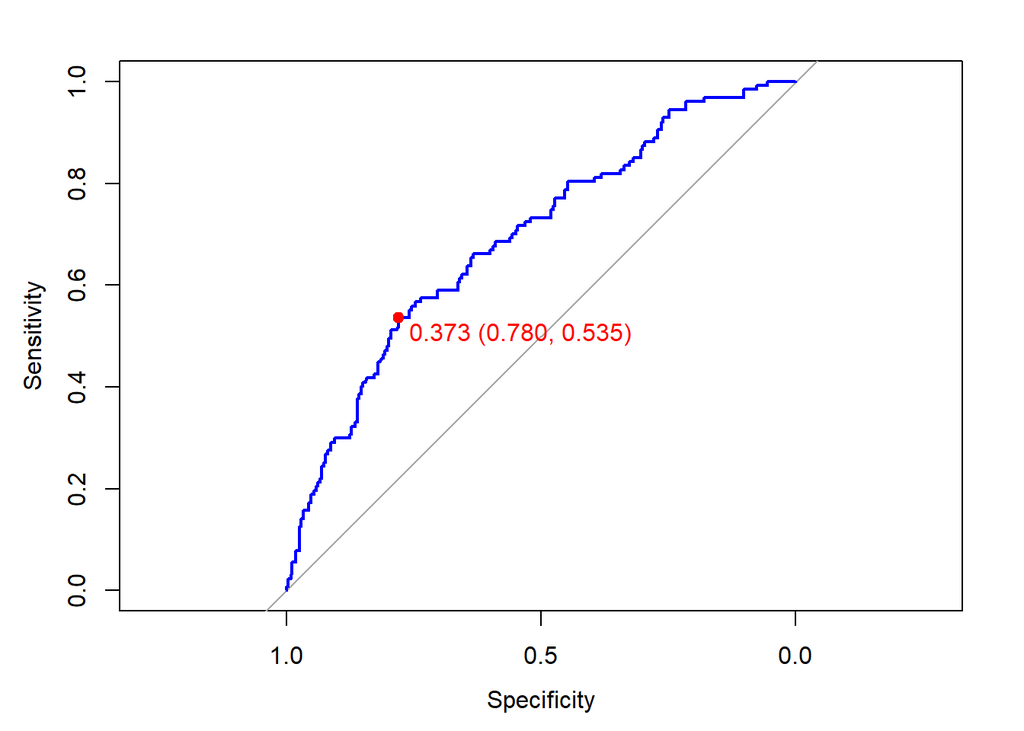

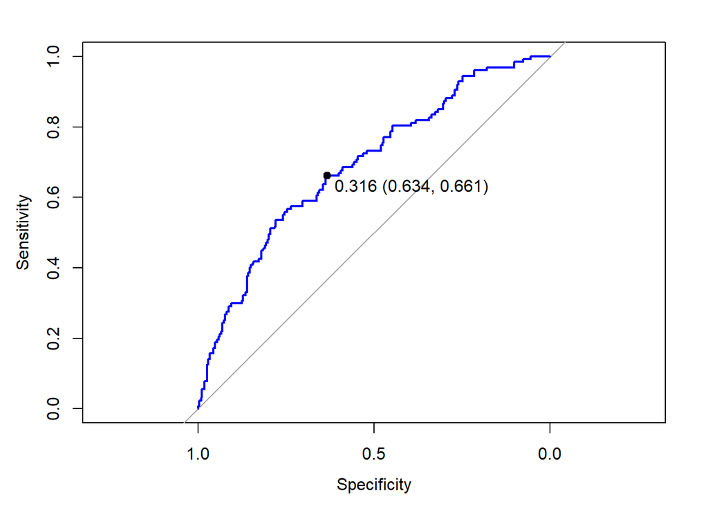

PARTE 2

Respuestas 1, 2 y 3

Modelo Logit Ordenado: A. estabpol (Índice de Estabilidad Política): El coeficiente estimado para estabpol es 0.32153 con un valor t de 4.034, lo que indica que es estadísticamente significativo. Esto sugiere que un aumento en el índice de estabilidad política está asociado con un aumento en la probabilidad de que una deuda sea clasificada en una categoría superior de ratsp. B. inf03 (Inflación en 2003): El coeficiente estimado para inf03 es -0.17749 con un valor t de -2.989, lo que también indica significación estadística. En este caso, un aumento en la inflación en 2003 está asociado con una disminución en la probabilidad de que una deuda sea clasificada en una categoría superior de ratsp. C. debt (Cociente Deuda/PIB): El coeficiente estimado para debt es -0.03768 con un valor t de -3.064, lo que indica significación estadística. Esto sugiere que un aumento en el cociente de deuda sobre el PIB está asociado con una disminución en la probabilidad de que una deuda sea clasificada en una categoría superior de ratsp. Modelo Probit Ordenado: A. estabpol (Índice de Estabilidad Política): El coeficiente estimado para estabpol es 0.16721 con un valor t de 4.635, lo que indica significación estadística. Esto sugiere que un aumento en el índice de estabilidad política está asociado con un aumento en la probabilidad de que una deuda sea clasificada en una categoría superior de ratsp. B. inf03 (Inflación en 2003): El coeficiente estimado para inf03 es -0.09362 con un valor t de -3.066, lo que indica significación estadística. En este caso, un aumento en la inflación en 2003 está asociado con una disminución en la probabilidad de que una deuda sea clasificada en una categoría superior de ratsp. C. debt (Cociente Deuda/PIB): El coeficiente estimado para debt es -0.01878 con un valor t de -2.987, lo que también indica significación estadística. Esto sugiere que un aumento en el cociente de deuda sobre el PIB está asociado con una disminución en la probabilidad de que una deuda sea clasificada en una categoría superior de ratsp. En resumen, en ambos modelos Logit y Probit ordenados, los coeficientes estimados para las variables estabpol, inf03, y debt son estadísticamente significativos, lo que sugiere que estas variables tienen un impacto significativo en la probabilidad de clasificación de la deuda según la calificación de S&P. Los signos de los coeficientes indican la dirección de la relación entre cada variable independiente y la probabilidad de clasificación.

```
## Call:
## polr(formula = ratsp ~ estabpol + inf03 + debt, data = Obligatorio_DEAN2_2023,
##     Hess = TRUE, method = "logistic")
##
## Coefficients:
##             Value Std. Error t value
## estabpol  0.32153    0.07971   4.034
## inf03    -0.17749    0.05938  -2.989
## debt     -0.03768    0.01230  -3.064
##
## Intercepts:
##     Value   Std. Error t value
## 0|1 10.1881  4.6803     2.1768
## 1|2 16.3328  5.2154     3.1316
## 2|3 20.4221  5.6600     3.6081
## 3|4 23.1880  5.9399     3.9038
##
## Residual Deviance: 79.08869
## AIC: 93.08869
```

```
## Call:
## polr(formula = ratsp ~ estabpol + inf03 + debt, data = Obligatorio_DEAN2_2023,
##     Hess = TRUE, method = "probit")
##
## Coefficients:
##             Value Std. Error t value
## estabpol  0.16721   0.036073   4.635
## inf03    -0.09362   0.030536  -3.066
## debt     -0.01878   0.006285  -2.987
##
## Intercepts:
##     Value   Std. Error t value
## 0|1  5.6455  2.2195     2.5435
## 1|2  8.4584  2.4077     3.5130
## 2|3 10.6177  2.5997     4.0842
## 3|4 12.0829  2.6850     4.5001
##
## Residual Deviance: 82.32951
## AIC: 96.32951
```